# Deep Neural Networks

- Convolutional Neural Networks (CNNs)
- Recurrent Neural Networks (RNNs)
- Generative Adversarial Networks (GANs)

# CNN

- Great for computer vision
  - Image Classification
  - Style Transfer
  - Objet Detection

## Dog Breed Classifier

If you'd like, try using a photo of a dog of your choosing or youself!

```python
import helper
%matplotlib inline

dog_classifier = helper.create_dog_breed_classifier()

# Get the class names
dog_class_names = helper.get_class_names()
```

#### Can correctly classify images of dog (Top-1 accuracy: 84% on test ste)

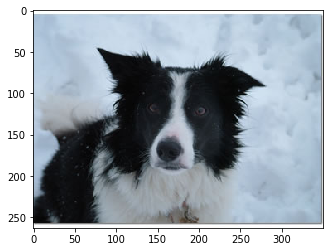

```
This looks like a Border collie to me.
```

```python
img = """assets/Border_Collie.jpg"""

helper.run_app(img, dog_classifier, dog_class_names)
```

#### Also can tell you what dog breed a human is most closely related to

```
Hello, human!
```

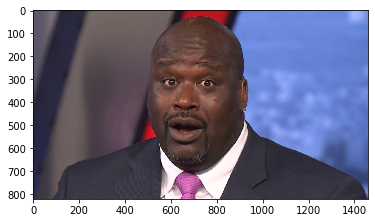

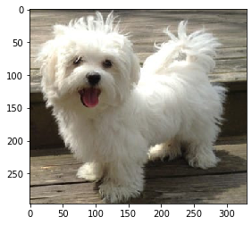

```
You look like a Maltese.
```

```python
img = """assets/shaq.jpg"""

helper.run_app(img, dog_classifier, dog_class_names)
```

# Style Transfer

[figure not shown]

*These were all generated by implementing this paper: https://www.cv-foundation.org/openaccess/content_cvpr_2016/papers/Gatys_Image_Style_Transfer_CVPR_2016_paper.pdf*

### As you can see, using this method, we can not only transfer the color pallette, but also the patterns and artist styles within the images

### Bonus: *Take a look in /assets to view these images enlarged*

# Recurrent Neural Networks (RNN)

- This is an example of a script I generated from using a Seinfeld dataset containing all of its scripts ever televised.

**jerry**: i mean, i like it.

**jerry**:(to the drake) i don't like this guy! i'm gonna go see the baby!(kramer enters the apartment. george enters. kramer enters...

**jerry**: what are you talking about?

**kramer**: yeah, but then i was wondering if it was a legitimate- hundred dollars.

**george**: what is he doing here?

**george**:(pointing) oh yeah, yeah....

**george**: what? what is this guy?

**george**: i don't know.

**jerry**: well, i don't know what you did to me.

**jerry**: what happened to the auto show?

**jerry**:(getting up to leave) hey, hey hey hey hey hey hey hey hey hey hey hey, hey, i gotta tell you something else, you know i just got to go out and get the job out of the car!

**elaine**:(to george) so?

**jerry**:(to jerry) hey, hey, hey!

**jerry**: hey..(to jerry) i can't believe i'm doing this!

**elaine**: oh, yeah, sure, i was just curious.

**elaine**:(pointing the door on the couch)

**jerry**:(pause, to himself) oh! my god!

**jerry**:(to george) hey, what happened? you think you're gonna be able to do it. i'm not getting this, i'm looking scared to you!

**george**: well it's a little bit of a dandy.

**elaine**:(to kramer, rebox) : i don't know.

**newman**: i can't believe it!

**elaine**: well, maybe.

**elaine**:(to jerry) i don't know.

**jerry**: well, you know, it's the only reason i ever heard.(jerry looks at kramer and hurriedly, elaine, jerry.(to elaine) you know, i think he might have a little more time.

#### Could still use some work

Obviously this script is not perfectd, but I personally find it enertaining.

# GANs

- Neural networks with an imagination
- They are able to generate new content

```python
# Instantiate the network
generator_network = helper.create_gan()
```

```python
import torch

# Load a pretrained network
generator_network.load_state_dict(torch.load('models/generator_mnist.pt'))
generator_network.eval()
```

```
Generator(
  (fc1): Linear(in_features=112, out_features=32, bias=True)
  (fc2): Linear(in_features=32, out_features=64, bias=True)
  (fc3): Linear(in_features=64, out_features=128, bias=True)
  (fc4): Linear(in_features=128, out_features=784, bias=True)
  (dropout): Dropout(p=0.3)
)
```

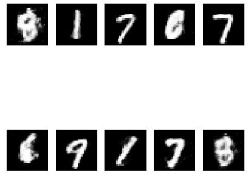

```python
# Generate handwritten digits
generated_image = generator_network.forward(helper.generate_latent_vector())

helper.view_samples(0, [generated_image])
```

### How did the network learn to draw these?

This network is actually not **a** neural network, but two of them. The first neural network generates content similar to what is found in the dataset. The second network is a 'detective' which is a classifier that looks at both content from the dataset and the content generated by the first network and tries to determine if it is looking at content from the dataset or not.

In the below cells for viewing samples, try changing the second parameter which determines which epoch the sample came from. (-1 will reference the largest epoch available)

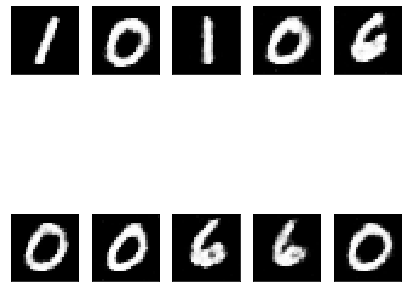

```python
helper.view_saved_samples('data/train_samples_mnist.pkl', -1)
```

### This can also be applied to more complicated tasks such as generating human faces

- However, we will need to combine the power of GANs with Convolutional Networks (DCGANs)
- This network was trained on a dataset of celebrity headshots

[figure not shown]

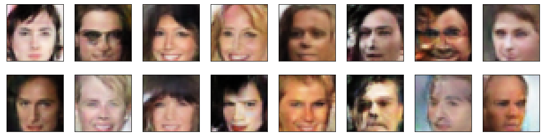

```python
# Again try playing with the 2nd parameter here which will show you the progress the GAN made.

# To me it's fascinating that the GAN learned to generate two eyes, a nose, and mouth almost
# immediately.

helper.view_saved_face_samples('data/train_samples_faces.pkl', -1)
```